# CBER Species distribution model

Vivienne Groner

Last compiled on 02 March, 2022

The code below demonstrates how to download and preprocess occurrence data from GBIF, download CHELSA climate data, and run a basic species distribution model. The code was written for South Africa (see reference Ferguson-Gow, Groner, Williams et al.) but can be adjusted to any other study area. For a more detailed introduction to species distribution models in R, go to [SDM Introduction](https://rspatial.org/raster/sdm/1_sdm_introduction.html).

# Set up your working environment

### Libraries

```r
set.seed(2237)
library(CoordinateCleaner)
library(dplyr)
library(lwgeom)
library(raster)
library(sp)
library(readr)
library(sf)
library(dismo)
library(rgdal)
library(stringr)
library(vroom)
library(ggplot2)
```

### Sourcing and directories

Set the directories to your project folder, the climate data and the SA_functions_CBER.R file (see SA_functions_CBER_markdown.html). The lower level folder structure for evaluation files, current and future projections, and figures will be created throughout the process.

```r
base_dir_in<-"Y:/SHEFS_joint_project/05_code_vivienne/pipeline_for_pc/my_experiment/"
climate_path<-paste0(base_dir_in,"CHELSA/")

source(paste0(base_dir_in,"/SA_functions_CBER.R"))
memory.limit(size=500000000)
```

# PART 1 - preprocessing of occurrence data

### Select study area

Make sure to select a study area that is big enough to capture the full range of the species you consider at current and future climate. If you are not sure, you can start by looking at the current distribution on the GBIF website or IUCN website and add around 10 % to the current range.

```r
xmin <- 15
xmax <- 35
ymin <- -35
ymax <- -20

ext_occ <- raster::extent(xmin, xmax, ymin, ymax)
```

### Load species occurrences points from GBIF

In this section, the gbifData function loads occurrence records for all species in your list. Check the [GBIF guidelines](https://www.gbif.org/citation-guidelines) for correct citation.

```r
if(!dir.exists(paste0(base_dir_in, "points/raw"))){
  dir.create(paste0(base_dir_in, "/points/raw/"), recursive = TRUE)
}

sp_names <- c('Amietia_delalandii','Certhilauda_subcoronata')
min_occ <-  20 # minimum number of occurrence points needed for the species to be included in the models

spxy_out <- lapply(X = sp_names,
                   FUN = gbifData,
                   ext_occ = ext_occ,
                   out_dir = paste0(base_dir_in, "/points/raw/"),
                   min_occ = min_occ)
```

```
## [1] "Amietia_delalandii done!"
## [1] "Certhilauda_subcoronata done!"
```

### Load reference climate data

This section downloads bioclimatic variables (climatologies, typically 1979-2013) from [CHELSA](https://chelsa-climate.org/) or reads data that you have already selected for your species and downloaded. For more information on bioclimatic variables see [WorldClim](https://www.worldclim.org/data/bioclim.html).

```r
bioclim_layers <- c(1, 5, 6, 13, 14) #the number of the bioclim layers to be included as environmental variables
# download climate layers
bio_layers1<-chelsa_bioclim_get(bioclim_layers)
```

```
## [1] "file already downloaded"
```

```r
# alternatively, you can read them directly from storage
# bio_layers <- list.files(climate_path, pattern = 'tif')
# bio_layers1<-paste(climate_path, bio_layers, sep="/")
bio_layers2 <-lapply(bio_layers1,raster::raster)
env_layers <- raster::stack(bio_layers2)
env_crop <- raster::crop(env_layers, ext_occ)
```

### Clean occurrence points

This step removes occurrence records that are errors, for example points in the ocean, duplicates, and so on (check [CoordinateCleaner](https://www.rdocumentation.org/packages/CoordinateCleaner/versions/2.0-20) for details on the package).

```r
if(!dir.exists(paste0(base_dir_in,"/points/cleaned_raw"))){
  dir.create(paste0(base_dir_in,"/points/cleaned_raw/"))
}

sp_names <- gsub(".csv", "", list.files(paste0(base_dir_in,"/points/raw/")))

lapply(X = sp_names,
       FUN = cc_wrapper,
       in_dir = paste0(base_dir_in,"/points/raw/"),
       out_dir = paste0(base_dir_in,"/points/cleaned_raw/"),
       min_occ = min_occ)
```

```
## [1] "Amietia_delalandii cleaned!"
## [1] "Certhilauda_subcoronata cleaned!"
```

### Rarefy occurrence points

This step makes sure that there is only one occurrence record per grid cell. The model can only account for one point per grid cell and you might end up with less unique points than total occurrence.

```r
if(!dir.exists(paste0(base_dir_in,"/points/rarefied",sep=''))){
  dir.create(paste0(base_dir_in,"/points/rarefied/",sep=''))
}

ref_map <- env_crop[[1]]
ref_map[!is.na(ref_map)] <- 0   #ref_map should be full of non-1 values

sp_names <- gsub(".csv", "", list.files(paste0(base_dir_in,"/points/cleaned_raw/"),pattern='csv'))

lapply(X = sp_names,
       FUN = rarefyPoints,
       in_dir = paste0(base_dir_in,"/points/cleaned_raw/"),
       out_dir = paste0(base_dir_in,"/points/rarefied/"),
       ref_map = ref_map,
       min_occ = min_occ)
```

```
## [1] "Amietia_delalandii rarefied!"
## [1] "Certhilauda_subcoronata rarefied!"
```

### Extract the environmental data for each occurrence point

This step extracts bioclimatic data at all locations where occurrences were recorded.

```r
if(!dir.exists(paste0(base_dir_in,"/environmental/presence/"))){
  dir.create(paste0(base_dir_in,"/environmental/presence/"), recursive = TRUE)
}

sp_names <- gsub(".csv", "", list.files(paste0(base_dir_in,"/points/rarefied/"),pattern='csv'))

lapply(X= sp_names,
       FUN = ras_extract,
       in_dir = paste0(base_dir_in,"/points/rarefied/"),
       out_dir = paste0(base_dir_in,"/environmental/presence/"),
       raster_in = env_crop)
```

```
## [1] "Amietia_delalandii"
## [1] "Certhilauda_subcoronata"
```

```
## [[1]]
## [1] "Amietia_delalandii"
##
## [[2]]
## [1] "Certhilauda_subcoronata"
```

### Background Data - create background and pseudoabsence points

This part selects background points and pseudoabsences from the same ecoregions as the species occurrence records. Background data are not attempting to guess at absence locations, but rather to characterize environments in the study region. A closely related but different concept, that of “pseudo-absences”, is also used for generating the non-presence class for logistic models. In this case, researchers sometimes try to guess where absences might occur – they may sample the whole region except at presence locations, or they might sample at places unlikely to be suitable for the species.

```r
if(!dir.exists(paste0(base_dir_in,"/points/background/"))){
  dir.create(paste0(base_dir_in,"/points/background/"))
}

if(!dir.exists(paste0(base_dir_in,"/points/pseudoabsence/"))){
  dir.create(paste0(base_dir_in,"/points/pseudoabsence/"))
}

# If you haven't downloaded WWF ecoregions
#load_ecoreg<-wwf_ecoregions_get()
# else
ecoreg <-
  sf::st_read(paste0(base_dir_in,"/WWF_Ecoregions/wwf_terr_ecos.shp")) %>%
  sf::st_crop(.,ext_occ) %>%  ##cropping to the area of interest
  dplyr::select(OBJECTID, ECO_NAME) ##just selecting out the columns we're interested in
  lapply(X = sp_names,
         background_sampler,
         in_dir = paste0(base_dir_in,"/points/rarefied/"),
         out_dir = paste0(base_dir_in,"/points/background/"),
         dens_abs = "density", density = 100, type = "background",
         polygon = ecoreg)
```

```
## [1] "Amietia_delalandii"
## [1] "Certhilauda_subcoronata"
```

```
## [[1]]
## [1] "Amietia_delalandii"
##
## [[2]]
## [1] "Certhilauda_subcoronata"
```

```r
  lapply(X = sp_names,
         background_sampler,
         in_dir = paste0(base_dir_in,"/points/rarefied/"),
         out_dir = paste0(base_dir_in,"/points/pseudoabsence/"),
         dens_abs = "density", density = 250, type = "pseudoabsence", buffer = 25, # you can play with the buffer
         polygon = ecoreg)
```

```
## [1] "Amietia_delalandii"
## [1] "Certhilauda_subcoronata"
```

```
## [[1]]
## [1] "Amietia_delalandii"
##
## [[2]]
## [1] "Certhilauda_subcoronata"
```

## Extract environmental data for background points and pseudoabsences

This step extracts bioclimatic data at the locations of background points and pseudoabsences.

```r
 if(!dir.exists(paste0(base_dir_in,"/environmental/background/"))){
   dir.create(paste0(base_dir_in,"/environmental/background/"))
 }

if(!dir.exists(paste0(base_dir_in,"/environmental/pseudoabsence/"))){
  dir.create(paste0(base_dir_in,"/environmental/pseudoabsence/"))
}

 lapply(X= sp_names,
        FUN = ras_extract,
        in_dir = paste0(base_dir_in,"/points/background/"),
        out_dir = paste0(base_dir_in,"/environmental/background/",sep=''),
        raster_in = env_crop)
```

```
## [1] "Amietia_delalandii"
## [1] "Certhilauda_subcoronata"
```

```
## [[1]]
## [1] "Amietia_delalandii"
##
## [[2]]
## [1] "Certhilauda_subcoronata"
```

```r
 lapply(X= sp_names,
        FUN = ras_extract,
        in_dir = paste0(base_dir_in,"/points/pseudoabsence/",sep=''),
        out_dir = paste0(base_dir_in,"/environmental/pseudoabsence/",sep=''),
        raster_in = env_crop)
```

```
## [1] "Amietia_delalandii"
## [1] "Certhilauda_subcoronata"
```

```
## [[1]]
## [1] "Amietia_delalandii"
##
## [[2]]
## [1] "Certhilauda_subcoronata"
```

## Plot occurrence points on map

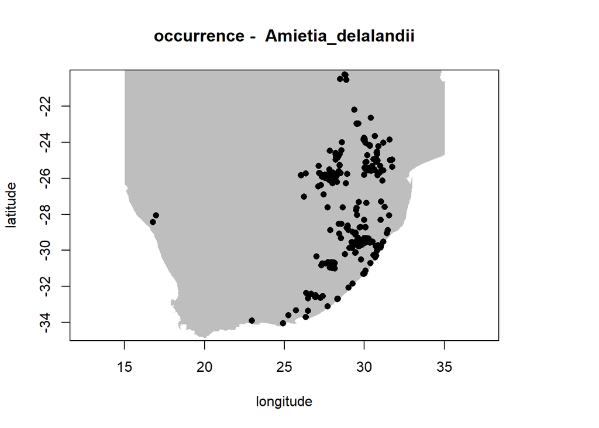

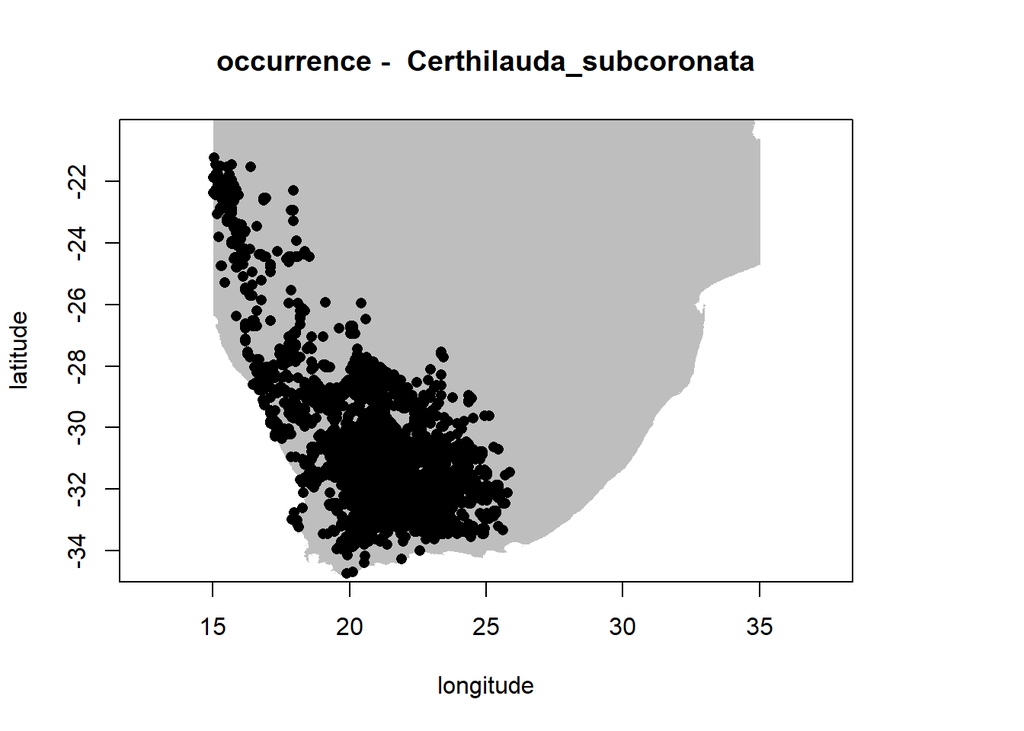

```r
if(!dir.exists(paste0(base_dir_in,"/plot_points/"))){
  dir.create(paste0(base_dir_in,"/plot_points/"))
}

points_in_list<-list.files(paste0(base_dir_in,"environmental/presence/"),pattern = "*.csv", full.names = TRUE)
points_in<-lapply(points_in_list,read.csv)

for (i in 1:length(points_in)){
  #tiff(paste0(base_dir_in,"/plot_points/", sp_names[[i]], ".png")) # this part saves the plot
  plot(ref_map,legend = FALSE, main=paste('occurrence - ', sp_names[[i]]),xlab="longitude", ylab="latitude",col='grey')
  box()
  points(points_in[[i]]$x,points_in[[i]]$y,pch=16)
  #dev.off()

}
```

# PART 2 - Species distribution model

## Load and prepare future climate data

This example includes two climate scenarios (RCP4.5 and RCP 8.5) from five General circulation models. The models were selected because they represent the South African climate well and are different in their structure. For more information on model selection see [CHELSA future](https://chelsa-climate.org/future/) . If you don’t have access to this data set, you can download it from the CHELSA ‘envicloud’ using [wget](https://www.gnu.org/software/wget/). Select all files that you want to download. Download the file (envidatS3paths.txt), install wget and then run the command: wget –no-host-directories –force-directories –input-file=envidatS3paths.txt.

```r
climate_path_future<-c(paste(base_dir_in,'CHELSA_future/2061-2080/rcp45/ACCESS1-0/',sep=''), # you can select your own future scenarios
                        paste(base_dir_in,'CHELSA_future/2061-2080/rcp45/CNRM-CM5/',sep=''),
                        paste(base_dir_in,'CHELSA_future/2061-2080/rcp45/GFDL-ESM2G/',sep=''),
                        paste(base_dir_in,'CHELSA_future/2061-2080/rcp45/HadGEM2-CC/',sep=''),
                        paste(base_dir_in,'CHELSA_future/2061-2080/rcp45/MPI-ESM-MR/',sep=''),
                        paste(base_dir_in,'CHELSA_future/2061-2080/rcp85/ACCESS1-0/',sep=''),
                        paste(base_dir_in,'CHELSA_future/2061-2080/rcp85/CNRM-CM5/',sep=''),
                        paste(base_dir_in,'CHELSA_future/2061-2080/rcp85/GFDL-ESM2G/',sep=''),
                        paste(base_dir_in,'CHELSA_future/2061-2080/rcp85/HadGEM2-CC/',sep=''),
                        paste(base_dir_in,'CHELSA_future/2061-2080/rcp85/MPI-ESM-MR/',sep='')
)

climate_scen_name<-c('rcp45_ACCESS1-0')#,'rcp45_CNRM-CM5','rcp45_GFDL-ESM2G','rcp45_HadGEM2-CC','rcp45_MPI-ESM-MR',
                     #'rcp85_ACCESS1-0','rcp85_CNRM-CM5','rcp85_GFDL-ESM2G','rcp85_HadGEM2-CC','rcp85_MPI-ESM-MR')

env_crop_future<-list()
for (fut in 1:length(climate_scen_name)){

  bio_layers_future <- list.files(climate_path_future[[fut]], pattern = 'tif')
  bio_layers1_future<-paste0(climate_path_future[[fut]], bio_layers_future)
  bio_layers2_future <-lapply(bio_layers1_future,raster)
  env_layers_future <- raster::stack(bio_layers2_future)
  env_crop_future[[fut]] <- raster::crop(env_layers_future, ext_occ)
  names(env_crop_future[[fut]])<-c('CHELSA_bio10_01','CHELSA_bio10_13','CHELSA_bio10_14','CHELSA_bio10_05','CHELSA_bio10_06') #check order
}
```

## Create folders for predictions and evaluation

```r
  if(!dir.exists(paste0(base_dir_in,"predictions/bioclim/"))){
    dir.create(paste0(base_dir_in,"predictions/bioclim"), recursive = TRUE)
  }

  if(!dir.exists(paste0(base_dir_in,"predictions/glm/"))){
    dir.create(paste0(base_dir_in,"predictions/glm"), recursive = TRUE)
  }

  if(!dir.exists(paste0(base_dir_in,"predictions/rf/"))){
    dir.create(paste0(base_dir_in,"predictions/rf"), recursive = TRUE)
  }

  if(!dir.exists(paste0(base_dir_in,"evaluation/bioclim/"))){
    dir.create(paste0(base_dir_in,"evaluation/bioclim"), recursive = TRUE)
  }

  if(!dir.exists(paste0(base_dir_in,"evaluation/glm/"))){
    dir.create(paste0(base_dir_in,"evaluation/glm"), recursive = TRUE)
  }

  if(!dir.exists(paste0(base_dir_in,"evaluation/rf/"))){
    dir.create(paste0(base_dir_in,"evaluation/rf"), recursive = TRUE)
  }


  for (fut in 1:length(climate_scen_name)){
    if(!dir.exists(paste0(base_dir_in,"future/",climate_scen_name[[fut]],"/predictions/bioclim/"))){
      dir.create(paste0(base_dir_in,"future/",climate_scen_name[[fut]],"/predictions/bioclim/"), recursive = TRUE)
    }

    if(!dir.exists(paste0(base_dir_in,"future/",climate_scen_name[[fut]],"/predictions/glm/"))){
      dir.create(paste0(base_dir_in,"future/",climate_scen_name[[fut]],"/predictions/glm/"), recursive = TRUE)
    }

    if(!dir.exists(paste0(base_dir_in,"future/",climate_scen_name[[fut]],"/predictions/rf/"))){
      dir.create(paste0(base_dir_in,"future/",climate_scen_name[[fut]],"/predictions/rf/"), recursive = TRUE)
    }
  }
```

## Fit Bioclim Models

```r
  # present
  lapply(
    X = sp_names,
    fitBC,
    pres_dir = paste0(base_dir_in,"environmental/presence/"),
    backg_dir = paste0(base_dir_in, "environmental/pseudoabsence/"),
    predictor_names = bioclim_layers,
    predictors = env_crop,
    pred_out_dir = paste0(base_dir_in,"predictions/bioclim/"),
    eval_out_dir = paste0(base_dir_in,"evaluation/bioclim/"),
    overwrite = TRUE,
    threads = 4,
    eval = TRUE
  )
```

```
## [1] "Amietia_delalandii"
## Fitting bioclim model...
## Done.
## ...
## Evaluating bioclim model...
## Done.
## ...
## Predicting from bioclim model...
## Done.
## ...
## Writing bioclim predictions...
## Done.
## ...
## [1] "Certhilauda_subcoronata"
## Fitting bioclim model...
## Done.
## ...
## Evaluating bioclim model...
## Done.
## ...
## Predicting from bioclim model...
## Done.
## ...
## Writing bioclim predictions...
## Done.
## ...
```

```r
  # future
  for (fut in 1:length(climate_scen_name)){
  lapply(
    X = sp_names,
    fitBC_future,
    pres_dir = paste0(base_dir_in,"environmental/presence/"),
    backg_dir = paste0(base_dir_in, "environmental/pseudoabsence/"),
    predictor_names = bioclim_layers,
    predictors_future = env_crop_future[[fut]],
    pred_out_dir_future = paste0(base_dir_in,"future/",climate_scen_name[[fut]],"/predictions/bioclim/"),
    eval_out_dir = paste0(base_dir_in,"evaluation/bioclim/"),
    overwrite = TRUE,
    threads = 4,
    eval = TRUE
  )
  }
```

```
## [1] "Amietia_delalandii"
## Read bioclim model...
## Done.
## ...
## Writing bioclim future predictions...
## Done.
## ...
## [1] "Certhilauda_subcoronata"
## Read bioclim model...
## Done.
## ...
## Writing bioclim future predictions...
## Done.
## ...
```

## Fit GLM Models

```r
  # present
  lapply(
    X = sp_names,
    fitGLM,
    pres_dir = paste0(base_dir_in,"environmental/presence/"),
    backg_dir = paste0(base_dir_in, "environmental/pseudoabsence/"),
    predictor_names = bioclim_layers,   #need to think about which ones we want to include
    predictors = env_crop,
    pred_out_dir =  paste0(base_dir_in,"predictions/glm/"),
    eval_out_dir =  paste0(base_dir_in,"evaluation/glm/"),
    overwrite = TRUE,
    threads = 4,
    eval = TRUE
  )
```

```
## [1] "Amietia_delalandii"
## Fitting GLM...
## Done.
## ...
## Evaluating GLM...
## Done.
## ...
## Predicting from GLM...
## Done.
## ...
## Writing GLM predictions...
## Done.
## ...
## [1] "Certhilauda_subcoronata"
## Fitting GLM...
## Done.
## ...
## Evaluating GLM...
## Done.
## ...
## Predicting from GLM...
## Done.
## ...
## Writing GLM predictions...
## Done.
## ...
```

```r
  # future
  for (fut in 1:length(climate_scen_name)){
  lapply(
    X = sp_names,
    fitGLM_future,
    pres_dir = paste0(base_dir_in,"environmental/presence/"),
    backg_dir = paste0(base_dir_in, "environmental/pseudoabsence/"),
    predictor_names = bioclim_layers,   #need to think about which ones we want to include
    predictors_future = env_crop_future[[fut]],
    pred_out_dir_future = paste0(base_dir_in,"future/",climate_scen_name[[fut]],"/predictions/glm/"),
    eval_out_dir =  paste0(base_dir_in,"evaluation/glm/"),
    overwrite = TRUE,
    threads = 4,
    eval = TRUE
    )
  }
```

```
## [1] "Amietia_delalandii"
## Read GLM...
## Done.
## ...
## Predicting future from GLM...
## Done.
## ...
## Writing GLM future predictions...
## Done.
## ...
## [1] "Certhilauda_subcoronata"
## Read GLM...
## Done.
## ...
## Predicting future from GLM...
## Done.
## ...
## Writing GLM future predictions...
## Done.
## ...
```

## Fit Random Forest Models

```r
  # present
  lapply(
  X = sp_names,
  fitRF,
  pres_dir =  paste0(base_dir_in,"environmental/presence/"),
  backg_dir =  paste0(base_dir_in,"environmental/pseudoabsence/"),
  predictor_names = bioclim_layers,
  predictors = env_crop,
  pred_out_dir =  paste0(base_dir_in,"predictions/rf/"),
  eval_out_dir =  paste0(base_dir_in,"evaluation/rf/"),
  overwrite = TRUE,
  threads = 4,
  eval = TRUE
  )
```

```
## [1] "Amietia_delalandii"
## Fitting random forest model...
## Done.
## ...
## Evaluating Random Forest model...
## Done.
## ...
## Predicting from random forest...
## Done.
## ...
## Writing random forest predictions...
## Done.
## ...
## [1] "Certhilauda_subcoronata"
## Fitting random forest model...
## Done.
## ...
## Evaluating Random Forest model...
## Done.
## ...
## Predicting from random forest...
## Done.
## ...
## Writing random forest predictions...
## Done.
## ...
```

```r
  # future
  for (fut in 1:length(climate_scen_name)){
    lapply(
      X = sp_names,
      fitRF_future,
      pres_dir =  paste0(base_dir_in,"environmental/presence/"),
      backg_dir =  paste0(base_dir_in,"environmental/pseudoabsence/"),
      predictor_names = bioclim_layers,
      predictors_future = env_crop_future[[fut]],
      pred_out_dir_future = paste0(base_dir_in,"future/",climate_scen_name[[fut]],"/predictions/rf/"),
      eval_out_dir =  paste0(base_dir_in,"evaluation/rf/"),
      overwrite = TRUE,
      threads = 4,
      eval = TRUE
      )
  }
```

```
## [1] "Amietia_delalandii"
## Read random forest model...
## Done.
## ...
## Done.
## ...
## Writing random forest future predictions...
## Done.
## ...
## [1] "Certhilauda_subcoronata"
## Read random forest model...
## Done.
## ...
## Done.
## ...
## Writing random forest future predictions...
## Done.
## ...
```

##Create directories for ensemble model output

```r
if(!dir.exists( paste0(base_dir_in,"predictions/ensemble/majority_pa"))){
  dir.create(paste0(base_dir_in,"predictions/ensemble/majority_pa"), recursive = TRUE)
}

if(!dir.exists( paste0(base_dir_in,"predictions/ensemble/weighted"))){
  dir.create(paste0(base_dir_in,"predictions/ensemble/weighted"), recursive = TRUE)
}


for (fut in 1:length(climate_scen_name)){

  if(!dir.exists( paste0(base_dir_in,"future/",climate_scen_name[[fut]],"/predictions/ensemble/majority_pa"))){
    dir.create(paste0(base_dir_in,"future/",climate_scen_name[[fut]],"/predictions/ensemble/majority_pa"), recursive = TRUE)
  }

  if(!dir.exists( paste0(base_dir_in,"future/",climate_scen_name[[fut]],"/predictions/ensemble/weighted"))){
    dir.create(paste0(base_dir_in,"future/",climate_scen_name[[fut]],"/predictions/ensemble/weighted"), recursive = TRUE)
  }

}
```

## Get evaluation and AUCs for ensemble model

This part reads the evaluation files from the different algorithms and run an ensemble model. You can select the threshold and calculate the presence absence by majority or weighted by AUC. You can select from the following thresholds:

- kappa: the threshold at which kappa is highest (“max kappa”)
- spec_sens: the threshold at which the sum of the sensitivity (true positive rate) and specificity (true negative rate) is highest
- no_omission: the highest threshold at which there is no omission
- prevalence: modeled prevalence is closest to observed prevalence
- equal_sens_spec: equal sensitivity and specificity
- sensitivity: fixed (specified) sensitivity

```r
eval_files <-
  list.files(
  paste0(base_dir_in,"evaluation"),
  full.names = TRUE,
  recursive = TRUE,
  pattern = c("*eval"))

for (s in 1:length(sp_names)){

  eval_files1<-grep(eval_files,pattern=sp_names[[s]],value=TRUE)
  evals_out <- lapply(eval_files1, get_eval, threshold = "spec_sens") # select threshold here
  eval_df <- do.call(rbind, evals_out)
  eval_df$sp_name <- as.character(eval_df$sp_name)

  preds <- list.files(paste0(base_dir_in,"predictions"),pattern=sp_names[[s]], full.names = TRUE, recursive = TRUE)
  preds <- preds[!grepl("/ensemble/", preds)]

  ensemble_model(sp_names[[s]],
                 eval_df = eval_df,
                 preds = preds,
                 out_dir = paste0(base_dir_in,"predictions/ensemble/"),
                 method = "majority_pa")

  ensemble_model(sp_names[[s]],
                 eval_df = eval_df,
                 preds = preds,
                 out_dir = paste0(base_dir_in,"predictions/ensemble/"),
                 method = "weighted")

# future
  for (fut in 1:length(climate_scen_name)){

    predsf <- list.files(paste0(base_dir_in, "future/",climate_scen_name[[fut]],"/predictions"),
                         pattern=sp_names[[s]], full.names = TRUE, recursive = TRUE)
    predsf <- predsf[!grepl("/ensemble/", predsf)]

    ensemble_model_f(sp_names[[s]],
                     eval_df = eval_df,
                     preds = predsf,
                     out_dir = paste0(base_dir_in, "future/", climate_scen_name[[fut]], "/predictions/ensemble/"),
                     method = "majority_pa")

    ensemble_model_f(sp_names[[s]],
                     eval_df = eval_df,
                     preds = predsf,
                     out_dir = paste0(base_dir_in, "future/", climate_scen_name[[fut]], "/predictions/ensemble/"),
                     method = "weighted")

  }
}
```

## Create plots

```r
if(!dir.exists(paste0(base_dir_in, "plots/ensemble/majority_pa"))){
  dir.create(paste0(base_dir_in, "plots/ensemble/majority_pa"), recursive = TRUE)
}

if(!dir.exists(paste0(base_dir_in, "plots/ensemble/weighted"))){
  dir.create(paste0(base_dir_in, "plots/ensemble/weighted"), recursive = TRUE)
}

for ( fut in 1:length(climate_scen_name)){

  if(!dir.exists(paste0(base_dir_in, "plots/future/ensemble/majority_pa"))){
    dir.create(paste0(base_dir_in, "plots/future/ensemble/majority_pa"), recursive = TRUE)
  }

    if(!dir.exists(paste0(base_dir_in, "plots/future/ensemble/weighted"))){
    dir.create(paste0(base_dir_in, "plots/future/ensemble/weighted"), recursive = TRUE)
    }

}

lapply(FUN=ggplot_out,
      X = sp_names,
      points_dir = paste0(base_dir_in, "points/rarefied/"),
      rast_dir = paste0(base_dir_in,"predictions/ensemble/majority_pa/"),
      out_dir = paste0(base_dir_in, "plots/ensemble/majority_pa/"))
```

```
## [[1]]
## [1] "Y:/SHEFS_joint_project/05_code_vivienne/pipeline_for_pc/my_experiment/plots/ensemble/majority_pa/Amietia_delalandii.png"
##
## [[2]]
## [1] "Y:/SHEFS_joint_project/05_code_vivienne/pipeline_for_pc/my_experiment/plots/ensemble/majority_pa/Certhilauda_subcoronata.png"
```

```r
lapply(FUN=ggplot_out,
      X = sp_names,
      points_dir = paste0(base_dir_in, "points/rarefied/"),
      rast_dir = paste0(base_dir_in,"predictions/ensemble/weighted/"),
      out_dir = paste0(base_dir_in, "plots/ensemble/weighted/"))
```

```
## [[1]]
## [1] "Y:/SHEFS_joint_project/05_code_vivienne/pipeline_for_pc/my_experiment/plots/ensemble/weighted/Amietia_delalandii.png"
##
## [[2]]
## [1] "Y:/SHEFS_joint_project/05_code_vivienne/pipeline_for_pc/my_experiment/plots/ensemble/weighted/Certhilauda_subcoronata.png"
```

```r
for (fut in 1:length(climate_scen_name)){

  lapply(FUN=ggplot_outf,
        X = sp_names,
        points_dir = paste0(base_dir_in, "points/rarefied/"),
        rast_dir = paste0(base_dir_in,"future/",climate_scen_name[[fut]],"/predictions/ensemble/majority_pa/"),
        out_dir = paste0(base_dir_in, "plots/future/ensemble/majority_pa/"))

  lapply(FUN=ggplot_outf,
        X = sp_names,
        points_dir = paste0(base_dir_in, "points/rarefied/"),
        rast_dir = paste0(base_dir_in,"future/",climate_scen_name[[fut]],"/predictions/ensemble/weighted/"),
        out_dir = paste0(base_dir_in, "plots/future/ensemble/weighted/"))

}
```

Plot for illustration:

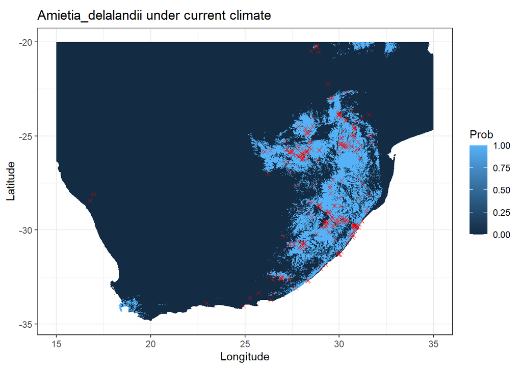

```r
# for illustration
  points <- read.csv(paste0(base_dir_in, "points/rarefied/",sp_names[[1]],".csv"))
  ras <- raster(paste0(base_dir_in,"predictions/ensemble/majority_pa/",  sp_names[[1]], "_ensemble.tif"))

  ras.p <-  rasterToPoints(ras)
  df <- data.frame(ras.p)
  colnames(df) <- c("Longitude", "Latitude", "Prob")

  ggplot(df, aes(y = Latitude, x = Longitude))+
    geom_tile(aes(fill = Prob))+
    geom_point(data = points, aes(x = x, y = y), colour = "red", shape = 4)+
    coord_equal()+
    theme_bw()+
    ggtitle(paste0(sp_names[[1]],' under current climate'))
```

END